# Lab Assignment Four: Multi-Layer Perceptron

Team members: Long Zhang,Qinyu Chen, Zhengwen Zhang

## Business understanding

In this lab, we will compare the performance of multi-layer perceptrons programmed via our own various implementations. We use a specific dataset chosen by instructor, the US census dataset is available from Kaggle. The objective of the classification is to predict, for each country, what the child poverty rate will be. we will convert this from regression to four levels of classification by quantizing the variable of interest.

data source:https://www.kaggle.com/muonneutrino/us-census-demographic-data

## 1. Load, Split, and Balance

Load the data into memory and save it to a pandas data frame. Do not normalize or one-hot encode any of the variables until asked to do so. Remove any observations that having missing data. Encode any string data as integers for now.

### 1.1 Load data

```python
import pandas as pd
import numpy as np
import seaborn as sns
from matplotlib import pyplot as plt
import warnings
warnings.filterwarnings('ignore')
from scipy.special import expit
import sys
from sklearn.metrics import classification_report, confusion_matrix, precision_score, accuracy_score, f1_score
```

We chose "acs2017_census_tract_data", the American Community Survey data for 2017 for each census tract in the US,including DC and Puerto Rico.

```python
#Load the data into memory and save it to a pandas data frame
df = pd.read_csv("/Users/chenqinyu/Desktop/acs2017_census_tract_data.csv")
#df = pd.read_csv("/Users/terrence/Desktop/acs2017_census_tract_data.csv")
# df = pd.read_csv(r"C:\Users\tony\Dropbox\smu\CSE7324\assignment\Lab4\acs2017_census_tract_data.csv")
```

```python
df.head()
```

|  | TractId | State | County | TotalPop | Men | Women | Hispanic | White | Black | Native | ... | Walk | OtherTransp | WorkAtHome | MeanCommute | Employed | PrivateWork | PublicWork | SelfEmployed | FamilyWork | Unemployment |
| --- | --- | --- | --- | --- | --- | --- | --- | --- | --- | --- | --- | --- | --- | --- | --- | --- | --- | --- | --- | --- | --- |
| 0 | 1001020100 | Alabama | Autauga County | 1845 | 899 | 946 | 2.4 | 86.3 | 5.2 | 0.0 | ... | 0.5 | 0.0 | 2.1 | 24.5 | 881 | 74.2 | 21.2 | 4.5 | 0.0 | 4.6 |
| 1 | 1001020200 | Alabama | Autauga County | 2172 | 1167 | 1005 | 1.1 | 41.6 | 54.5 | 0.0 | ... | 0.0 | 0.5 | 0.0 | 22.2 | 852 | 75.9 | 15.0 | 9.0 | 0.0 | 3.4 |
| 2 | 1001020300 | Alabama | Autauga County | 3385 | 1533 | 1852 | 8.0 | 61.4 | 26.5 | 0.6 | ... | 1.0 | 0.8 | 1.5 | 23.1 | 1482 | 73.3 | 21.1 | 4.8 | 0.7 | 4.7 |
| 3 | 1001020400 | Alabama | Autauga County | 4267 | 2001 | 2266 | 9.6 | 80.3 | 7.1 | 0.5 | ... | 1.5 | 2.9 | 2.1 | 25.9 | 1849 | 75.8 | 19.7 | 4.5 | 0.0 | 6.1 |
| 4 | 1001020500 | Alabama | Autauga County | 9965 | 5054 | 4911 | 0.9 | 77.5 | 16.4 | 0.0 | ... | 0.8 | 0.3 | 0.7 | 21.0 | 4787 | 71.4 | 24.1 | 4.5 | 0.0 | 2.3 |

5 rows × 37 columns

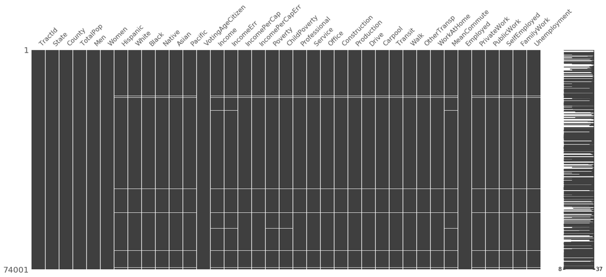

```python
# use the missingno to directly find if there is any missing data
import missingno as mn
mn.matrix(df)
```

The white lines in the graph above indicate there are many missing data in the dataset.

```python
#Remove any observations that having missing data.
df = df.dropna()
```

```python
df.isna().sum()
```

```
TractId             0
State               0
County              0
TotalPop            0
Men                 0
Women               0
Hispanic            0
White               0
Black               0
Native              0
Asian               0
Pacific             0
VotingAgeCitizen    0
Income              0
IncomeErr           0
IncomePerCap        0
IncomePerCapErr     0
Poverty             0
ChildPoverty        0
Professional        0
Service             0
Office              0
Construction        0
Production          0
Drive               0
Carpool             0
Transit             0
Walk                0
OtherTransp         0
WorkAtHome          0
MeanCommute         0
Employed            0
PrivateWork         0
PublicWork          0
SelfEmployed        0
FamilyWork          0
Unemployment        0
dtype: int64
```

Validations suggest that there is no missing data

```python
# find if dataset has the same row
df.duplicated().sum()
```

```
0
```

no duplicate has been found as well.

```python
df.info()
```

```
<class 'pandas.core.frame.DataFrame'>
Int64Index: 72718 entries, 0 to 74000
Data columns (total 37 columns):
TractId             72718 non-null int64
State               72718 non-null object
County              72718 non-null object
TotalPop            72718 non-null int64
Men                 72718 non-null int64
Women               72718 non-null int64
Hispanic            72718 non-null float64
White               72718 non-null float64
Black               72718 non-null float64
Native              72718 non-null float64
Asian               72718 non-null float64
Pacific             72718 non-null float64
VotingAgeCitizen    72718 non-null int64
Income              72718 non-null float64
IncomeErr           72718 non-null float64
IncomePerCap        72718 non-null float64
IncomePerCapErr     72718 non-null float64
Poverty             72718 non-null float64
ChildPoverty        72718 non-null float64
Professional        72718 non-null float64
Service             72718 non-null float64
Office              72718 non-null float64
Construction        72718 non-null float64
Production          72718 non-null float64
Drive               72718 non-null float64
Carpool             72718 non-null float64
Transit             72718 non-null float64
Walk                72718 non-null float64
OtherTransp         72718 non-null float64
WorkAtHome          72718 non-null float64
MeanCommute         72718 non-null float64
Employed            72718 non-null int64
PrivateWork         72718 non-null float64
PublicWork          72718 non-null float64
SelfEmployed        72718 non-null float64
FamilyWork          72718 non-null float64
Unemployment        72718 non-null float64
dtypes: float64(29), int64(6), object(2)
memory usage: 21.1+ MB
```

There are two string type data in our dataset, State and County. Our classification task is to predict, for each county, what the child poverty rate will be. Because county data is unique, we can get rid of it.

```python
df.drop("County", axis =1,inplace=True)
```

But for 'State', it is quite important. we need to use it and transform its type to integer.

```python
from sklearn import preprocessing

le = preprocessing.LabelEncoder()
df.State = le.fit_transform(df.State)
df.State
```

```
0         0
1         0
2         0
3         0
4         0
         ..
73996    39
73997    39
73998    39
73999    39
74000    39
Name: State, Length: 72718, dtype: int64
```

```python
# View the labels
print(len(list(le.classes_)))
print(list(le.classes_))
```

```
52
['Alabama', 'Alaska', 'Arizona', 'Arkansas', 'California', 'Colorado', 'Connecticut', 'Delaware', 'District of Columbia', 'Florida', 'Georgia', 'Hawaii', 'Idaho', 'Illinois', 'Indiana', 'Iowa', 'Kansas', 'Kentucky', 'Louisiana', 'Maine', 'Maryland', 'Massachusetts', 'Michigan', 'Minnesota', 'Mississ…
```

We can see there are 52 states, and we encode them into integers.

```python
df.info()
```

```
<class 'pandas.core.frame.DataFrame'>
Int64Index: 72718 entries, 0 to 74000
Data columns (total 36 columns):
TractId             72718 non-null int64
State               72718 non-null int64
TotalPop            72718 non-null int64
Men                 72718 non-null int64
Women               72718 non-null int64
Hispanic            72718 non-null float64
White               72718 non-null float64
Black               72718 non-null float64
Native              72718 non-null float64
Asian               72718 non-null float64
Pacific             72718 non-null float64
VotingAgeCitizen    72718 non-null int64
Income              72718 non-null float64
IncomeErr           72718 non-null float64
IncomePerCap        72718 non-null float64
IncomePerCapErr     72718 non-null float64
Poverty             72718 non-null float64
ChildPoverty        72718 non-null float64
Professional        72718 non-null float64
Service             72718 non-null float64
Office              72718 non-null float64
Construction        72718 non-null float64
Production          72718 non-null float64
Drive               72718 non-null float64
Carpool             72718 non-null float64
Transit             72718 non-null float64
Walk                72718 non-null float64
OtherTransp         72718 non-null float64
WorkAtHome          72718 non-null float64
MeanCommute         72718 non-null float64
Employed            72718 non-null int64
PrivateWork         72718 non-null float64
PublicWork          72718 non-null float64
SelfEmployed        72718 non-null float64
FamilyWork          72718 non-null float64
Unemployment        72718 non-null float64
dtypes: float64(29), int64(7)
memory usage: 20.5 MB
```

All the string data are converted to integers now.

### 1.2 split data

Assume you are equally interested in the classification performance for each class in the dataset. Split the dataset into 80% for training and 20% for testing.

```python
#Split the dataset into 80% for training and 20% for testing.
from sklearn.model_selection import train_test_split

train, test = train_test_split(df, test_size=0.2)
print(train.shape, test.shape)
```

```
(58174, 36) (14544, 36)
```

### 1.3 Balance the dataset

[5 points] Balance the dataset so that about the same number of instances are within each class. Choose a method for balancing the dataset and explain your reasoning for selecting this method. One option is to choose quantization thresholds for the "ChildPoverty" variable that equally divide the data into four classes. Should balancing of the dataset be done for both the training and testing set? Explain.

```python
df['ChildPoverty'].describe()
```

```
count    72718.000000
mean        21.148476
std         18.572714
min          0.000000
25%          6.200000
50%         16.300000
75%         31.600000
max        100.000000
Name: ChildPoverty, dtype: float64
```

```python
# 0 means low poverty rate, 1 means normal, 2 means high, 3 means very high
df['ChildPovertyLevel'] = pd.cut(df.ChildPoverty, [-1,6.21,16.31,31.61,100], labels=['0','1','2','3'])
```

```
[18229 18171 18148 18170]
```

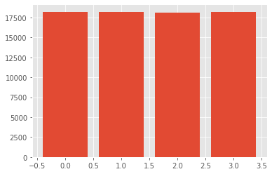

```python
target =  df['ChildPovertyLevel']
target_names = 'ChildPovertyLevel'
y = target
y = y.astype(int)
vals = np.bincount(y)
print(vals)
plt.bar(range(len(vals)),vals)
plt.show()
```

We see our four class have very close numbers, which will help us to predict.

### Should balancing of the dataset be done for both the training and testing set? Explain.

Here, we do think the balanced dataset shoulb be used in both trainning and testing set. Because we want our balanced data('ChildPovertyLevel') as our target, we should use it in both our trainning and testing set. If we not use our balance data in our train and test, we don't have clear class so that our prediction will be terrible. Therefore, we will use the balanced data and split a new train and test. Also, we will use X as our feature, y as our target.

```python
df1 = df.drop("ChildPovertyLevel",axis=1)
```

```python
df2 = df1.drop(["ChildPoverty","TractId"], axis=1 )
```

From our common sense, we think Id is useless and we delete it. We try the data which have TracId, and get worse results. So dropping Id seems right.

```python
df2
```

|  | State | TotalPop | Men | Women | Hispanic | White | Black | Native | Asian | Pacific | ... | Walk | OtherTransp | WorkAtHome | MeanCommute | Employed | PrivateWork | PublicWork | SelfEmployed | FamilyWork | Unemployment |
| --- | --- | --- | --- | --- | --- | --- | --- | --- | --- | --- | --- | --- | --- | --- | --- | --- | --- | --- | --- | --- | --- |
| 0 | 0 | 1845 | 899 | 946 | 2.4 | 86.3 | 5.2 | 0.0 | 1.2 | 0.0 | ... | 0.5 | 0.0 | 2.1 | 24.5 | 881 | 74.2 | 21.2 | 4.5 | 0.0 | 4.6 |
| 1 | 0 | 2172 | 1167 | 1005 | 1.1 | 41.6 | 54.5 | 0.0 | 1.0 | 0.0 | ... | 0.0 | 0.5 | 0.0 | 22.2 | 852 | 75.9 | 15.0 | 9.0 | 0.0 | 3.4 |
| 2 | 0 | 3385 | 1533 | 1852 | 8.0 | 61.4 | 26.5 | 0.6 | 0.7 | 0.4 | ... | 1.0 | 0.8 | 1.5 | 23.1 | 1482 | 73.3 | 21.1 | 4.8 | 0.7 | 4.7 |
| 3 | 0 | 4267 | 2001 | 2266 | 9.6 | 80.3 | 7.1 | 0.5 | 0.2 | 0.0 | ... | 1.5 | 2.9 | 2.1 | 25.9 | 1849 | 75.8 | 19.7 | 4.5 | 0.0 | 6.1 |
| 4 | 0 | 9965 | 5054 | 4911 | 0.9 | 77.5 | 16.4 | 0.0 | 3.1 | 0.0 | ... | 0.8 | 0.3 | 0.7 | 21.0 | 4787 | 71.4 | 24.1 | 4.5 | 0.0 | 2.3 |
| ... | ... | ... | ... | ... | ... | ... | ... | ... | ... | ... | ... | ... | ... | ... | ... | ... | ... | ... | ... | ... | ... |
| 73996 | 39 | 6011 | 3035 | 2976 | 99.7 | 0.3 | 0.0 | 0.0 | 0.0 | 0.0 | ... | 0.5 | 0.0 | 3.6 | 26.9 | 1576 | 59.2 | 33.8 | 7.0 | 0.0 | 20.8 |
| 73997 | 39 | 2342 | 959 | 1383 | 99.1 | 0.9 | 0.0 | 0.0 | 0.0 | 0.0 | ... | 0.0 | 0.0 | 1.3 | 25.3 | 666 | 58.4 | 35.4 | 6.2 | 0.0 | 26.3 |
| 73998 | 39 | 2218 | 1001 | 1217 | 99.5 | 0.2 | 0.0 | 0.0 | 0.2 | 0.0 | ... | 3.4 | 0.0 | 3.4 | 23.5 | 560 | 57.5 | 34.5 | 8.0 | 0.0 | 23.0 |
| 73999 | 39 | 4380 | 1964 | 2416 | 100.0 | 0.0 | 0.0 | 0.0 | 0.0 | 0.0 | ... | 0.0 | 0.0 | 0.0 | 24.1 | 1062 | 67.7 | 30.4 | 1.9 | 0.0 | 29.5 |
| 74000 | 39 | 3001 | 1343 | 1658 | 99.2 | 0.8 | 0.0 | 0.0 | 0.0 | 0.0 | ... | 4.9 | 0.0 | 8.9 | 21.6 | 759 | 75.9 | 19.1 | 5.0 | 0.0 | 17.9 |

72718 rows × 34 columns

```python
from sklearn.preprocessing import StandardScaler
X = df2.values
y = np.array(y)
X = StandardScaler().fit(X).transform(X)

print(X.shape)
print(y.shape)
```

```
(72718, 34)
(72718,)
```

```python
from sklearn.model_selection import train_test_split

X_train, X_test, y_train, y_test = train_test_split(X,y,test_size = 0.2)

print(X_train.shape)
print(y_train.shape)
print(X_test.shape)
print(y_test.shape)
```

```
(58174, 34)
(58174,)
(14544, 34)
(14544,)
```

## 2. Pre-processing

### 2.1 the example two-layer perceptron network from the class example and quantify performance using accuracy. Do not normalize or one-hot encode the data (not yet). Be sure that training converges by graphing the loss function versus the number of epochs.

#### Codes below are modifed from the instructor's ML notebook on github

Reference: https://github.com/eclarson/MachineLearningNotebooks/blob/master/07.%20MLP%20Neural%20Networks.ipynb

```python
import numpy as np
from scipy.special import expit
import pandas as pd
import sys

# start with a simple base classifier, which can't be fit or predicted
# it only has internal classes to be used by classes that will subclass it
class TwoLayerPerceptronBase(object):
    def __init__(self, n_hidden=30,
                 C=0.0, epochs=500, eta=0.001, random_state=None):
        np.random.seed(random_state)
        self.n_hidden = n_hidden
        self.l2_C = C
        self.epochs = epochs
        self.eta = eta

    @staticmethod
    def _encode_labels(y):
        """Encode labels into one-hot representation"""
        onehot = pd.get_dummies(y).values.T

        return onehot

    def _initialize_weights(self):
        """Initialize weights with small random numbers."""
        W1_num_elems = (self.n_features_ + 1)*self.n_hidden
        W1 = np.random.uniform(-1.0, 1.0,size=W1_num_elems)
        W1 = W1.reshape(self.n_hidden, self.n_features_ + 1) # reshape to be W

        W2_num_elems = (self.n_hidden + 1)*self.n_output_
        W2 = np.random.uniform(-1.0, 1.0, size=W2_num_elems)
        W2 = W2.reshape(self.n_output_, self.n_hidden + 1)
        return W1, W2

    @staticmethod
    def _sigmoid(z):
        """Use scipy.special.expit to avoid overflow"""
        # 1.0 / (1.0 + np.exp(-z))
        return expit(z)

    @staticmethod
    def _add_bias_unit(X, how='column'):
        """Add bias unit (column or row of 1s) to array at index 0"""
        if how == 'column':
            ones = np.ones((X.shape[0], 1))
            X_new = np.hstack((ones, X))
        elif how == 'row':
            ones = np.ones((1, X.shape[1]))
            X_new = np.vstack((ones, X))
        return X_new

    @staticmethod
    def _L2_reg(lambda_, W1, W2):
        """Compute L2-regularization cost"""
        # only compute for non-bias terms
        return (lambda_/2.0) * np.sqrt(np.mean(W1[:, 1:] ** 2) + np.mean(W2[:, 1:] ** 2))

    def _cost(self,A3,Y_enc,W1,W2):
        '''Get the objective function value'''
        cost = np.mean((Y_enc-A3)**2)
        L2_term = self._L2_reg(self.l2_C, W1, W2)
        return cost + L2_term

    def _feedforward(self, X, W1, W2):
        """Compute feedforward step
        """
        A1 = self._add_bias_unit(X, how='column')
        A1 = A1.T
        Z1 = W1 @ A1
        A2 = self._sigmoid(Z1)
        A2 = self._add_bias_unit(A2, how='row')
        Z2 = W2 @ A2
        A3 = self._sigmoid(Z2)
        return A1, Z1, A2, Z2, A3

    def _get_gradient(self, A1, A2, A3, Z1, Z2, Y_enc, W1, W2):
        """ Compute gradient step using backpropagation.
        """
        # vectorized backpropagation
        V2 = -2*(Y_enc-A3)*A3*(1-A3)  # last layer sensitivity
        V1 = A2*(1-A2)*(W2.T @ V2) # back prop the sensitivity

        grad2 = V2 @ A2.T # no bias on final layer
        grad1 = V1[1:,:] @ A1.T # dont back prop sensitivity of bias


        # regularize weights that are not bias terms
        grad1[:, 1:] += W1[:, 1:] * self.l2_C
        grad2[:, 1:] += W2[:, 1:] * self.l2_C

        return grad1, grad2

    def predict(self, X):
        """Predict class labels"""
        _, _, _, _, A3 = self._feedforward(X, self.W1, self.W2)
        y_pred = np.argmax(A3, axis=0)
        return y_pred
```

```python
from sklearn.metrics import accuracy_score
# just start with the vectorized version and minibatch
class TLPMiniBatch(TwoLayerPerceptronBase):
    def __init__(self, alpha=0.0, decrease_const=0.0, shuffle=True,
                 minibatches=1, **kwds):
        # need to add to the original initializer
        self.alpha = alpha
        self.decrease_const = decrease_const
        self.shuffle = shuffle
        self.minibatches = minibatches
        # but keep other keywords
        super().__init__(**kwds)


    def fit(self, X, y, print_progress=False):
        """ Learn weights from training data. With mini-batch"""
        X_data, y_data = X.copy(), y.copy()
        Y_enc = self._encode_labels(y)

        # init weights and setup matrices
        self.n_features_ = X_data.shape[1]
        self.n_output_ = Y_enc.shape[0]
        self.W1, self.W2 = self._initialize_weights()

        delta_W1_prev = np.zeros(self.W1.shape)
        delta_W2_prev = np.zeros(self.W2.shape)

        self.cost_ = []
        self.score_ = []
        # get starting acc
        self.score_.append(accuracy_score(y_data,self.predict(X_data)))
        for i in range(self.epochs):

            # adaptive learning rate
            self.eta /= (1 + self.decrease_const*i)

            if print_progress>0 and (i+1)%print_progress==0:
                sys.stderr.write('\rEpoch: %d/%d' % (i+1, self.epochs))
                sys.stderr.flush()

            if self.shuffle:
                idx_shuffle = np.random.permutation(y_data.shape[0])
                X_data, Y_enc, y_data = X_data[idx_shuffle], Y_enc[:, idx_shuffle], y_data[idx_shuffle]

            mini = np.array_split(range(y_data.shape[0]), self.minibatches)
            mini_cost = []
            for idx in mini:

                # feedforward
                A1, Z1, A2, Z2, A3 = self._feedforward(X_data[idx],
                                                       self.W1,
                                                       self.W2)

                cost = self._cost(A3,Y_enc[:, idx],self.W1,self.W2)
                mini_cost.append(cost) # this appends cost of mini-batch only

                # compute gradient via backpropagation
                grad1, grad2 = self._get_gradient(A1=A1, A2=A2, A3=A3, Z1=Z1, Z2=Z2,
                                                  Y_enc=Y_enc[:, idx],
                                                  W1=self.W1,W2=self.W2)

                # momentum calculations
                delta_W1, delta_W2 = self.eta * grad1, self.eta * grad2
                self.W1 -= (delta_W1 + (self.alpha * delta_W1_prev))
                self.W2 -= (delta_W2 + (self.alpha * delta_W2_prev))
                delta_W1_prev, delta_W2_prev = delta_W1, delta_W2

            self.cost_.append(mini_cost)
            self.score_.append(accuracy_score(y_data,self.predict(X_data)))

        return self
```

```python
class TLPMiniBatchCrossEntropy(TLPMiniBatch):
    def _cost(self,A3,Y_enc,W1,W2):
        '''Get the objective function value'''
        cost = -np.mean(np.nan_to_num((Y_enc*np.log(A3)+(1-Y_enc)*np.log(1-A3))))
        L2_term = self._L2_reg(self.l2_C, W1, W2)
        return cost + L2_term

    def _get_gradient(self, A1, A2, A3, Z1, Z2, Y_enc, W1, W2):
        """ Compute gradient step using backpropagation.
        """
        # vectorized backpropagation
        V2 = (A3-Y_enc) # <- this is only line that changed
        V1 = A2*(1-A2)*(W2.T @ V2)

        grad2 = V2 @ A2.T
        grad1 = V1[1:,:] @ A1.T

        # regularize weights that are not bias terms
        grad1[:, 1:] += W1[:, 1:] * self.l2_C
        grad2[:, 1:] += W2[:, 1:] * self.l2_C

        return grad1, grad2
```

```python
vals = { 'n_hidden':30,
         'C':0.1, 'epochs':20, 'eta':0.001,
         'alpha':0.001, 'decrease_const':1e-5, 'minibatches':50,
         'shuffle':True,'random_state':1}

nn_quad1 = TLPMiniBatch(**vals)

nn_cross1 = TLPMiniBatchCrossEntropy(**vals)

%time nn_cross1.fit(X_train, y_train, print_progress=1)
%time nn_quad1.fit(X_train, y_train, print_progress=1)
print("Done")
```

```
Epoch: 2/200
```

```
CPU times: user 7.74 s, sys: 512 ms, total: 8.25 s
Wall time: 2.07 s
```

```
Epoch: 20/20
```

```
CPU times: user 7.47 s, sys: 282 ms, total: 7.75 s
Wall time: 1.94 s
Done
```

```python
from sklearn.metrics import accuracy_score
import matplotlib.pyplot as plt
%matplotlib inline

plt.style.use('ggplot')

def print_result(nn,X_train,y_train,X_test,y_test,title="",color="red"):

    print("=================")
    print(title,":")
    yhat = nn.predict(X_train)
    print('Resubstitution acc:',accuracy_score(y_train,yhat))

    yhat = nn.predict(X_test)
    print('Validation acc:',accuracy_score(y_test,yhat))

    if hasattr(nn,'val_score_'):
        plt.plot(range(len(nn.val_score_)), nn.val_score_, color=color,label=title)
        plt.ylabel('Validation Accuracy')
    else:
        plt.plot(range(len(nn.score_)), nn.score_, color=color,label=title)
        plt.ylabel('Resub Accuracy')

    plt.xlabel('Epochs')
    plt.tight_layout()
    plt.legend(loc='best')
    plt.grid(True)
```

```
=================
Cross Entropy Loss :
Resubstitution acc: 0.7281775363564479
Validation acc: 0.7284103410341034
=================
Quadratic Loss :
Resubstitution acc: 0.7114346615326435
Validation acc: 0.7107398239823982
```

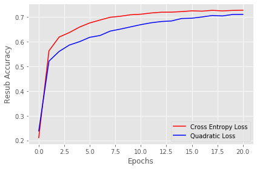

```python
print_result(nn_cross1,X_train,y_train,X_test,y_test,title="Cross Entropy Loss",color="red")
print_result(nn_quad1,X_train,y_train,X_test,y_test,title="Quadratic Loss",color="blue")

plt.show()
```

### 2.2 Now normalize the continuous numeric feature data. Use the example two-layer perceptron network from the class example and quantify performance using accuracy. Be sure that training converges by graphing the loss function versus the number of epochs.

```python
X_train1 = preprocessing.normalize(X_train)
X_test1 = preprocessing.normalize(X_test)
y_train1 = y_train
y_test1 = y_test
```

```python
print(np.min(X_train1),np.max(X_train1))
print(np.min(X_test1),np.max(X_test1))
print(np.unique(y_train))
```

```
-0.6570886513661907 0.9948517153341218
-0.6823211417871842 0.9970154115779829
[0 1 2 3]
```

we do normalize here and check if values are between -1 and 1.

```python
vals = { 'n_hidden':30,
         'C':0.1, 'epochs':20, 'eta':0.001,
         'alpha':0.001, 'decrease_const':1e-5, 'minibatches':50,
         'shuffle':True,'random_state':1}

nn_quad2 = TLPMiniBatch(**vals)

nn_cross2 = TLPMiniBatchCrossEntropy(**vals)

%time nn_cross2.fit(X_train1, y_train1, print_progress=1)
%time nn_quad2.fit(X_train1, y_train1, print_progress=1)
print("Done")
```

```
Epoch: 2/200
```

```
CPU times: user 8.52 s, sys: 609 ms, total: 9.13 s
Wall time: 2.31 s
```

```
Epoch: 20/20
```

```
CPU times: user 7.62 s, sys: 453 ms, total: 8.08 s
Wall time: 2.04 s
Done
```

```
=================
Cross Entropy Loss :
Resubstitution acc: 0.6650049850448654
Validation acc: 0.665497799779978
=================
Quadratic Loss :
Resubstitution acc: 0.6376559975246674
Validation acc: 0.6387513751375138
```

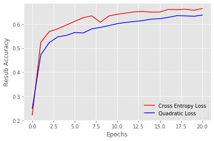

```python
print_result(nn_cross2,X_train1,y_train1,X_test1,y_test1,title="Cross Entropy Loss",color="red")
print_result(nn_quad2,X_train1,y_train1,X_test1,y_test1,title="Quadratic Loss",color="blue")

plt.show()
```

From the graph and results aboove, we can see the Resubstitution accuracy is about 67% for Cross Entropy Loss, and 64% for Quadratic Loss. when epochs is about 1, the increase of acc becomes slow.

### 2.3 Now normalize the continuous numeric feature data AND one hot encode the categorical data.

Because we delete Id and County, State is the left categorical data.

```python
df.head()
```

|  | TractId | State | TotalPop | Men | Women | Hispanic | White | Black | Native | Asian | ... | OtherTransp | WorkAtHome | MeanCommute | Employed | PrivateWork | PublicWork | SelfEmployed | FamilyWork | Unemployment | ChildPovertyLevel |
| --- | --- | --- | --- | --- | --- | --- | --- | --- | --- | --- | --- | --- | --- | --- | --- | --- | --- | --- | --- | --- | --- |
| 0 | 1001020100 | 0 | 1845 | 899 | 946 | 2.4 | 86.3 | 5.2 | 0.0 | 1.2 | ... | 0.0 | 2.1 | 24.5 | 881 | 74.2 | 21.2 | 4.5 | 0.0 | 4.6 | 2 |
| 1 | 1001020200 | 0 | 2172 | 1167 | 1005 | 1.1 | 41.6 | 54.5 | 0.0 | 1.0 | ... | 0.5 | 0.0 | 22.2 | 852 | 75.9 | 15.0 | 9.0 | 0.0 | 3.4 | 3 |
| 2 | 1001020300 | 0 | 3385 | 1533 | 1852 | 8.0 | 61.4 | 26.5 | 0.6 | 0.7 | ... | 0.8 | 1.5 | 23.1 | 1482 | 73.3 | 21.1 | 4.8 | 0.7 | 4.7 | 2 |
| 3 | 1001020400 | 0 | 4267 | 2001 | 2266 | 9.6 | 80.3 | 7.1 | 0.5 | 0.2 | ... | 2.9 | 2.1 | 25.9 | 1849 | 75.8 | 19.7 | 4.5 | 0.0 | 6.1 | 0 |
| 4 | 1001020500 | 0 | 9965 | 5054 | 4911 | 0.9 | 77.5 | 16.4 | 0.0 | 3.1 | ... | 0.3 | 0.7 | 21.0 | 4787 | 71.4 | 24.1 | 4.5 | 0.0 | 2.3 | 2 |

5 rows × 37 columns

```python
dfDummies = pd.get_dummies(df['State'], prefix = 'State')
dfDummies
```

|  | State_0 | State_1 | State_2 | State_3 | State_4 | State_5 | State_6 | State_7 | State_8 | State_9 | ... | State_42 | State_43 | State_44 | State_45 | State_46 | State_47 | State_48 | State_49 | State_50 | State_51 |
| --- | --- | --- | --- | --- | --- | --- | --- | --- | --- | --- | --- | --- | --- | --- | --- | --- | --- | --- | --- | --- | --- |
| 0 | 1 | 0 | 0 | 0 | 0 | 0 | 0 | 0 | 0 | 0 | ... | 0 | 0 | 0 | 0 | 0 | 0 | 0 | 0 | 0 | 0 |
| 1 | 1 | 0 | 0 | 0 | 0 | 0 | 0 | 0 | 0 | 0 | ... | 0 | 0 | 0 | 0 | 0 | 0 | 0 | 0 | 0 | 0 |
| 2 | 1 | 0 | 0 | 0 | 0 | 0 | 0 | 0 | 0 | 0 | ... | 0 | 0 | 0 | 0 | 0 | 0 | 0 | 0 | 0 | 0 |
| 3 | 1 | 0 | 0 | 0 | 0 | 0 | 0 | 0 | 0 | 0 | ... | 0 | 0 | 0 | 0 | 0 | 0 | 0 | 0 | 0 | 0 |
| 4 | 1 | 0 | 0 | 0 | 0 | 0 | 0 | 0 | 0 | 0 | ... | 0 | 0 | 0 | 0 | 0 | 0 | 0 | 0 | 0 | 0 |
| ... | ... | ... | ... | ... | ... | ... | ... | ... | ... | ... | ... | ... | ... | ... | ... | ... | ... | ... | ... | ... | ... |
| 73996 | 0 | 0 | 0 | 0 | 0 | 0 | 0 | 0 | 0 | 0 | ... | 0 | 0 | 0 | 0 | 0 | 0 | 0 | 0 | 0 | 0 |
| 73997 | 0 | 0 | 0 | 0 | 0 | 0 | 0 | 0 | 0 | 0 | ... | 0 | 0 | 0 | 0 | 0 | 0 | 0 | 0 | 0 | 0 |
| 73998 | 0 | 0 | 0 | 0 | 0 | 0 | 0 | 0 | 0 | 0 | ... | 0 | 0 | 0 | 0 | 0 | 0 | 0 | 0 | 0 | 0 |
| 73999 | 0 | 0 | 0 | 0 | 0 | 0 | 0 | 0 | 0 | 0 | ... | 0 | 0 | 0 | 0 | 0 | 0 | 0 | 0 | 0 | 0 |
| 74000 | 0 | 0 | 0 | 0 | 0 | 0 | 0 | 0 | 0 | 0 | ... | 0 | 0 | 0 | 0 | 0 | 0 | 0 | 0 | 0 | 0 |

72718 rows × 52 columns

```python
df2
```

|  | State | TotalPop | Men | Women | Hispanic | White | Black | Native | Asian | Pacific | ... | Walk | OtherTransp | WorkAtHome | MeanCommute | Employed | PrivateWork | PublicWork | SelfEmployed | FamilyWork | Unemployment |
| --- | --- | --- | --- | --- | --- | --- | --- | --- | --- | --- | --- | --- | --- | --- | --- | --- | --- | --- | --- | --- | --- |
| 0 | 0 | 1845 | 899 | 946 | 2.4 | 86.3 | 5.2 | 0.0 | 1.2 | 0.0 | ... | 0.5 | 0.0 | 2.1 | 24.5 | 881 | 74.2 | 21.2 | 4.5 | 0.0 | 4.6 |
| 1 | 0 | 2172 | 1167 | 1005 | 1.1 | 41.6 | 54.5 | 0.0 | 1.0 | 0.0 | ... | 0.0 | 0.5 | 0.0 | 22.2 | 852 | 75.9 | 15.0 | 9.0 | 0.0 | 3.4 |
| 2 | 0 | 3385 | 1533 | 1852 | 8.0 | 61.4 | 26.5 | 0.6 | 0.7 | 0.4 | ... | 1.0 | 0.8 | 1.5 | 23.1 | 1482 | 73.3 | 21.1 | 4.8 | 0.7 | 4.7 |
| 3 | 0 | 4267 | 2001 | 2266 | 9.6 | 80.3 | 7.1 | 0.5 | 0.2 | 0.0 | ... | 1.5 | 2.9 | 2.1 | 25.9 | 1849 | 75.8 | 19.7 | 4.5 | 0.0 | 6.1 |
| 4 | 0 | 9965 | 5054 | 4911 | 0.9 | 77.5 | 16.4 | 0.0 | 3.1 | 0.0 | ... | 0.8 | 0.3 | 0.7 | 21.0 | 4787 | 71.4 | 24.1 | 4.5 | 0.0 | 2.3 |
| ... | ... | ... | ... | ... | ... | ... | ... | ... | ... | ... | ... | ... | ... | ... | ... | ... | ... | ... | ... | ... | ... |
| 73996 | 39 | 6011 | 3035 | 2976 | 99.7 | 0.3 | 0.0 | 0.0 | 0.0 | 0.0 | ... | 0.5 | 0.0 | 3.6 | 26.9 | 1576 | 59.2 | 33.8 | 7.0 | 0.0 | 20.8 |
| 73997 | 39 | 2342 | 959 | 1383 | 99.1 | 0.9 | 0.0 | 0.0 | 0.0 | 0.0 | ... | 0.0 | 0.0 | 1.3 | 25.3 | 666 | 58.4 | 35.4 | 6.2 | 0.0 | 26.3 |
| 73998 | 39 | 2218 | 1001 | 1217 | 99.5 | 0.2 | 0.0 | 0.0 | 0.2 | 0.0 | ... | 3.4 | 0.0 | 3.4 | 23.5 | 560 | 57.5 | 34.5 | 8.0 | 0.0 | 23.0 |
| 73999 | 39 | 4380 | 1964 | 2416 | 100.0 | 0.0 | 0.0 | 0.0 | 0.0 | 0.0 | ... | 0.0 | 0.0 | 0.0 | 24.1 | 1062 | 67.7 | 30.4 | 1.9 | 0.0 | 29.5 |
| 74000 | 39 | 3001 | 1343 | 1658 | 99.2 | 0.8 | 0.0 | 0.0 | 0.0 | 0.0 | ... | 4.9 | 0.0 | 8.9 | 21.6 | 759 | 75.9 | 19.1 | 5.0 | 0.0 | 17.9 |

72718 rows × 34 columns

```python
df2.State = dfDummies
```

```python
df3 = pd.concat([dfDummies,df2], axis=1)
```

```python
df3= df3.drop("State", axis =  1 )
```

```python
df3.info()
```

```
<class 'pandas.core.frame.DataFrame'>
Int64Index: 72718 entries, 0 to 74000
Data columns (total 85 columns):
State_0             72718 non-null uint8
State_1             72718 non-null uint8
State_2             72718 non-null uint8
State_3             72718 non-null uint8
State_4             72718 non-null uint8
State_5             72718 non-null uint8
State_6             72718 non-null uint8
State_7             72718 non-null uint8
State_8             72718 non-null uint8
State_9             72718 non-null uint8
State_10            72718 non-null uint8
State_11            72718 non-null uint8
State_12            72718 non-null uint8
State_13            72718 non-null uint8
State_14            72718 non-null uint8
State_15            72718 non-null uint8
State_16            72718 non-null uint8
State_17            72718 non-null uint8
State_18            72718 non-null uint8
State_19            72718 non-null uint8
State_20            72718 non-null uint8
State_21            72718 non-null uint8
State_22            72718 non-null uint8
State_23            72718 non-null uint8
State_24            72718 non-null uint8
State_25            72718 non-null uint8
State_26            72718 non-null uint8
State_27            72718 non-null uint8
State_28            72718 non-null uint8
State_29            72718 non-null uint8
State_30            72718 non-null uint8
State_31            72718 non-null uint8
State_32            72718 non-null uint8
State_33            72718 non-null uint8
State_34            72718 non-null uint8
State_35            72718 non-null uint8
State_36            72718 non-null uint8
```

[output cut: 35 more lines]

```
Drive               72718 non-null float64
Carpool             72718 non-null float64
Transit             72718 non-null float64
Walk                72718 non-null float64
OtherTransp         72718 non-null float64
WorkAtHome          72718 non-null float64
MeanCommute         72718 non-null float64
Employed            72718 non-null int64
PrivateWork         72718 non-null float64
PublicWork          72718 non-null float64
SelfEmployed        72718 non-null float64
FamilyWork          72718 non-null float64
Unemployment        72718 non-null float64
dtypes: float64(28), int64(5), uint8(52)
memory usage: 22.5 MB
```

```python
from sklearn.preprocessing import StandardScaler
X3 = df3.values
y = np.array(y)
X3 = StandardScaler().fit(X3).transform(X3)

print(X.shape)
print(y.shape)
```

```
(72718, 34)
(72718,)
```

```python
#normalize data
X3 = preprocessing.normalize(X3)
print(np.min(X3),np.max(X3))
```

```
-0.5596922918857337 0.9934585014923557
```

```python
X_train2, X_test2, y_train2, y_test2 = train_test_split(X3,y,test_size = 0.2)

print(X_train2.shape)
print(y_train2.shape)
print(X_test2.shape)
print(y_test2.shape)
```

```
(58174, 85)
(58174,)
(14544, 85)
(14544,)
```

```python
vals = { 'n_hidden':30,
         'C':0.1, 'epochs':20, 'eta':0.001,
         'alpha':0.001, 'decrease_const':1e-5, 'minibatches':50,
         'shuffle':True,'random_state':1}

nn_quad3 = TLPMiniBatch(**vals)

nn_cross3 = TLPMiniBatchCrossEntropy(**vals)

%time nn_cross3.fit(X_train2, y_train2, print_progress=1)
%time nn_quad3.fit(X_train2, y_train2, print_progress=1)
print("Done")
```

```
Epoch: 1/200
```

```
CPU times: user 10.8 s, sys: 890 ms, total: 11.7 s
Wall time: 2.95 s
```

```
Epoch: 20/20
```

```
CPU times: user 10.3 s, sys: 880 ms, total: 11.2 s
Wall time: 2.83 s
Done
```

```
=================
Cross Entropy Loss :
Resubstitution acc: 0.6574414686973562
Validation acc: 0.652915291529153
=================
Quadratic Loss :
Resubstitution acc: 0.6035857943411146
Validation acc: 0.5954345434543454
```

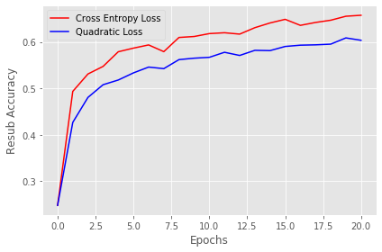

```python
print_result(nn_cross3,X_train2,y_train2,X_test2,y_test2,title="Cross Entropy Loss",color="red")
print_result(nn_quad3,X_train2,y_train2,X_test2,y_test2,title="Quadratic Loss",color="blue")

plt.show()
```

From the graph and results aboove, we can see the Resubstitution accuracy is about 66% for Cross Entropy Loss, and 60% for Quadratic Loss. when epochs is about 1, the increase of acc becomes slow.

### 2.4 Compare the performance of the three models you just trained. Are there any meaningful differences in performance? Explain, in your own words, why these models have (or do not have) different performances.

Here, we decide to use McNemar Testing to compare the performance of the three models.  
Citation: http://rasbt.github.io/mlxtend/user_guide/evaluate/mcnemar/

```python
#first we need to get the prediction value of model 1,2,3
y_pred1 = nn_cross1.predict(X_train)
y_pred2 = nn_cross2.predict(X_train1)
y_pred3 = nn_cross3.predict(X_train2)
print(y_pred1)
print(y_pred2)
print(y_pred3)
```

```
[2 0 3 ... 0 3 3]
[2 0 3 ... 0 3 3]
[2 0 3 ... 2 2 0]
```

##### model1 vs model2

```python
from statsmodels.stats.contingency_tables import mcnemar
from mlxtend.evaluate import mcnemar_table
```

```python
table1 = mcnemar_table(y_target=y_train,
                   y_model1=y_pred1,
                   y_model2=y_pred2)
print(table1)
```

```
[[35526  3160]
 [ 6835 12653]]
```

Now,we get the table,and ready for McNemar Testing.

```python
from mlxtend.evaluate import mcnemar

chi2, p = mcnemar(ary=table1, exact=True)

print('chi-squared:', chi2)
print('p-value:', p)
```

```
chi-squared: 3160
p-value: 1.227976305391974e-302
```

##### model1 vs model3

```python
table2 = mcnemar_table(y_target=y_train,
                   y_model1=y_pred1,
                   y_model2=y_pred3)
print(table2)
```

```
[[10595  3910]
 [31766 11903]]
```

```python
chi2, p = mcnemar(ary=table2, exact=True)

print('chi-squared:', chi2)
print('p-value:', p)
```

```
chi-squared: 3910
p-value: 0.0
```

##### model2 vs model3

```python
table3 = mcnemar_table(y_target=y_train,
                   y_model1=y_pred2,
                   y_model2=y_pred3)
print(table3)
```

```
[[ 9751  4754]
 [28935 14734]]
```

```python
chi2, p = mcnemar(ary=table3, exact=True)

print('chi-squared:', chi2)
print('p-value:', p)
```

```
chi-squared: 4754
p-value: 0.0
```

Since the p-value is less than our assumed significance threshold (α=0.05), we reject our null hypothesis and assume that there is significant difference between the two predictive models.  
Additionally, acc of model 2 (0.66) is similar to model 3(0.65). About accurancy, model 2 and model 3 are very close.

In conclusion, from McNemar testing perspective, three model shows totally different between each other. In model 1, we do not normalize the data or one-hot encoding data. we normalize the data in model 2 but do not one-hot encoding data. In model 3, we normalize data and do one-hot encoding.  
From accurancy perspective, compare the result, we find one-hot coding has less impact on our model. But normalization do influence our model. We do one-hot encoding for "State", but the function of one-hot coding is similar to the original data here. And why normalization change our result a lot? The goal of normalization is to change the values of numeric columns in the dataset to a common scale, without distorting differences in the ranges of values. For machine learning, every dataset does not require normalization. It is required only when features have different ranges.As for our data, we do fit-transform(x) at the beginning, so it is useless for us to do normalization. After fit-transform, we already have perfct data, although the value is not between 0 and 1, it is close to 0. This is why we do normalization but our accuracy go down.

## 3 Modeling

### 3.1 Adding a 3rd layer

[10 points] Add support for a third layer in the multi-layer perceptron. Add support for saving (and plotting after training is completed) the average magnitude of the gradient for each layer, for each epoch. Quantify the performance of the model and graph the magnitudes for each layer versus the number of epochs.

#### Codes below are modified from the instructor's ML notebook on github

Reference: https://github.com/eclarson/MachineLearningNotebooks/blob/master/07.%20MLP%20Neural%20Networks.ipynb

```python
from sklearn.metrics import accuracy_score
from sklearn.preprocessing import StandardScaler
from sklearn.metrics import accuracy_score
from sklearn.metrics import precision_score, recall_score, f1_score
```

We change TwoLayerPerceptronBase, and TwoLayerPerceptron to ThreeLayerPerceptronBase and ThreeLayerPerceptron. We use three layers this time, W1,W2,W3. Some place, in order to better our job, we create list of A,Z and use for loop function to finish.

```python
class ThreeLayerPerceptronBase(object):
    def __init__(self, n_hidden=30,phi_function='sigmoid', cost_function='quadratic', n_layers=3,
                 C=0.0, epochs=500, eta=0.001, random_state=None):
        np.random.seed(random_state)
        self.n_hidden = n_hidden
        self.l2_C = C
        self.epochs = epochs
        self.eta = eta
        self.phi_function = phi_function
        self.cost_function = cost_function
        self.n_layers=n_layers



    @staticmethod
    def _encode_labels(y):
        """Encode labels into one-hot representation"""
        onehot = pd.get_dummies(y).values.T
        return onehot

 #now, we have 3 layers, so we have W1, W2,W3
    def _initialize_weights(self):

        W = []
        """Initialize weights with small random numbers."""
        W1_num_elems = (self.n_features_ + 1)*self.n_hidden
        W1 = np.random.uniform(-1.0, 1.0, size=W1_num_elems)
        W1 = W1.reshape(self.n_hidden, self.n_features_ + 1) # reshape to be W

        W2_num_elems = (self.n_hidden + 1)*self.n_hidden
        W2 = np.random.uniform(-1.0, 1.0, size=W2_num_elems)
        W2 = W2.reshape(self.n_hidden, self.n_hidden + 1)

        W3_num_elems = (self.n_hidden + 1)*self.n_output_
        W3 = np.random.uniform(-1.0, 1.0, size=W3_num_elems)
        W3 = W3.reshape(self.n_output_, self.n_hidden + 1)
        W = [W1,W2,W3]
        return W

    @staticmethod
    def _sigmoid(z):
        """Use scipy.special.expit to avoid overflow"""
        # 1.0 / (1.0 + np.exp(-z))
        return expit(z)

    @staticmethod
    def _linear(z):
        return z

    @staticmethod
    def _add_bias_unit(X, how='column'):
        """Add bias unit (column or row of 1s) to array at index 0"""
        if how == 'column':
            ones = np.ones((X.shape[0], 1))
            X_new = np.hstack((ones, X))
        elif how == 'row':
            ones = np.ones((1, X.shape[1]))
            X_new = np.vstack((ones, X))
        return X_new


    @staticmethod
    def _L2_reg(lambda_, W):
        """Compute L2-regularization cost"""
        # only compute for non-bias terms
        return (lambda_/2.0) * np.sqrt(np.mean(W[0][:, 1:] ** 2) + np.mean(W[1][:, 1:] ** 2) + np.mean(W[2][:, 1:] ** 2))

    def _cost(self, A_last, Y_enc, W):
        '''Get the objective function value'''
        if 'quadratic' == self.cost_function:
            cost = np.mean((Y_enc - A_last) ** 2)
        elif 'crossentropy' == self.cost_function:
            cost = -np.mean((Y_enc * np.log(A_last) + (1 - Y_enc) * np.log(1 - A_last)))

        L2_term = self._L2_reg(self.l2_C, W)
        return cost + L2_term
```

```python
class ThreeLayerPerceptron(ThreeLayerPerceptronBase):
    def _feedforward(self, X, W):
        """Compute feedforward step"""
        if  'linear' == self.phi_function:
            activate = self._linear
        elif  'sigmoid' == self.phi_function:
            activate = self._sigmoid
        else:
            raise 'Not a valid of phi_function'

        #Initialize A,Z
        A, Z = [], []
        A.append(self._add_bias_unit(X.T, how='row'))
        Z.append(W[0] @ A[0])
        for i in range(1,self.n_layers):
            A.append(self._add_bias_unit(activate(Z[i-1]), how='row'))
            Z.append(W[i] @ A[i])
        #Last layer A
        A.append(activate(Z[-1]))
        return A,Z

    def _get_gradient(self, A, Z, Y_enc, W):
        """ Compute gradient step using backpropagation."""
        # vectorized backpropagation
        grad, V = [[]] * self.n_layers, [[]] * self.n_layers

        # First
        if 'crossentropy' == self.cost_function:
            V[-1] = A[-1] - Y_enc
        elif 'quadratic' == self.cost_function: # mse
            V[-1] = -2 * (Y_enc-A[-1]) * A[-1] * (1-A[-1])
        else:
            raise 'Not a valid of cost_function'
        grad[-1] = V[-1] @ A[-2].T

        # After first
        for i in range(self.n_layers-2, -1, -1): #We want to start at the last layer, including 0
            if 'linear' == self.phi_function:
                V[i] = W[i+1].T @ V[i+1]
            elif 'sigmoid' == self.phi_function:
                V[i] = A[i+1] * (1-A[i+1]) * (W[i+1].T @ V[i+1])
            V[i] = V[i][1:,:]

            grad[i] = V[i] @ A[i].T

        # regularize weights that are not bias terms
        for i in range(len(grad)):
            grad[i][:, 1:] += W[i][:, 1:] * self.l2_C

        return grad

    def predict(self, X):
        """Predict class labels"""
        A, _ = self._feedforward(X, self.W)
        y_pred = np.argmax(A[-1], axis=0)
        return [self.class_labels_[i] for i in y_pred] #get rid of index

    def fit(self, X, y, print_progress=False):
        """ Learn weights from training data."""

        X_data, y_data = X.copy(), y.copy()
        self.class_labels_ = np.unique(y)
        Y_enc = self._encode_labels(y)

        # init weights and setup matrices
        self.n_features_ = X_data.shape[1]
        self.n_output_ = Y_enc.shape[0]
        self.W = self._initialize_weights()

        self.magnitude_gradients = []
        for i in range(self.n_layers):
            self.magnitude_gradients.append(np.zeros([self.epochs, 1]))

        self.cost_ = []
        self.score_ = []
        gradients = [[]] * self.n_layers
        for epoch in range(self.epochs):
            if print_progress>0 and (epoch+1)%print_progress==0:
                sys.stderr.write('\rEpoch: %d/%d' % (epoch+1, self.epochs))
                sys.stderr.flush()

            # feedforward all instances
            A, Z = self._feedforward(X_data, self.W)
            cost = self._cost(A[-1], Y_enc, self.W)
            self.cost_.append(cost)

            self.score_.append(f1_score(y, self.predict(X_data), average='weighted'))

            # compute gradient via backpropagation
            grad = self._get_gradient(A, Z, Y_enc, self.W)

            for grad_idx in range(len(grad)):
                self.W[grad_idx] -= self.eta * grad[grad_idx]
                gradients[grad_idx].append(np.mean(grad[grad_idx]))

            for layer in range(self.n_layers):
                self.magnitude_gradients[layer][epoch] = average_magnitude(grad[layer])

        self.gradients_ = [[]] * self.n_layers
        for i in range(self.n_layers):
            self.gradients_[i] = np.array(gradients[i])


        return self
```

```python
def average_magnitude(gradient):
    '''
    Input: gradient
    Output: average mangintude
    '''
    absolute = np.abs(gradient)
    return np.mean(absolute)
```

```python
params3 = dict(n_hidden=50,
              C=0.1, # tradeoff L2 regularizer
              epochs=50, # iterations
              eta=0.001,  # learning rate
              n_layers=3,
              random_state=1)
```

```python
%%time
nn = ThreeLayerPerceptron(**params3)
clf = nn.fit(X_train2, y_train2, print_progress=100)
yhat = nn.predict(X_test2)
print('Test acc:',accuracy_score(y_test2,yhat))
```

```
Test acc: 0.2493124312431243
CPU times: user 51.8 s, sys: 3.8 s, total: 55.6 s
Wall time: 14 s
```

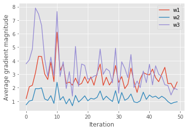

```python
ax = plt.subplot(1,1,1)
plt.plot(clf.magnitude_gradients[0][10:], label = 'W1' )
plt.plot(clf.magnitude_gradients[1][10:], label = 'W2' )
plt.plot(clf.magnitude_gradients[2][10:], label = 'W3' )
plt.legend()
plt.ylabel('Average gradient magnitude')
plt.xlabel('Iteration')
plt.show()
```

### 3.2 Repeat the previous step, adding support for a fourth layer.

```python
class FourLayerPerceptronBase(object):
    def __init__(self, n_hidden=30,phi_function='sigmoid', cost_function='quadratic', n_layers=4,
                 C=0.0, epochs=500, eta=0.001, random_state=None):
        np.random.seed(random_state)
        self.n_hidden = n_hidden
        self.l2_C = C
        self.epochs = epochs
        self.eta = eta
        self.phi_function = phi_function
        self.cost_function = cost_function
        self.n_layers=n_layers



    @staticmethod
    def _encode_labels(y):
        """Encode labels into one-hot representation"""
        onehot = pd.get_dummies(y).values.T
        return onehot

#now, we have 4 layers, so we have W1, W2,W3,W4

    def _initialize_weights(self):

        W = []
        """Initialize weights with small random numbers."""
        W1_num_elems = (self.n_features_ + 1)*self.n_hidden
        W1 = np.random.uniform(-1.0, 1.0, size=W1_num_elems)
        W1 = W1.reshape(self.n_hidden, self.n_features_ + 1) # reshape to be W

        W2_num_elems = (self.n_hidden + 1)*self.n_hidden
        W2 = np.random.uniform(-1.0, 1.0, size=W2_num_elems)
        W2 = W2.reshape(self.n_hidden, self.n_hidden + 1)

        W3_num_elems = (self.n_hidden + 1)*self.n_hidden
        W3 = np.random.uniform(-1.0, 1.0, size=W3_num_elems)
        W3 = W3.reshape(self.n_hidden, self.n_hidden + 1)

        W4_num_elems = (self.n_hidden + 1)*self.n_output_
        W4 = np.random.uniform(-1.0, 1.0, size=W4_num_elems)
        W4 = W4.reshape(self.n_output_, self.n_hidden + 1)
        W = [W1,W2,W3,W4]
        return W

    @staticmethod
    def _sigmoid(z):
        """Use scipy.special.expit to avoid overflow"""
        # 1.0 / (1.0 + np.exp(-z))
        return expit(z)

    @staticmethod
    def _linear(z):
        return z

    @staticmethod
    def _add_bias_unit(X, how='column'):
        """Add bias unit (column or row of 1s) to array at index 0"""
        if how == 'column':
            ones = np.ones((X.shape[0], 1))
            X_new = np.hstack((ones, X))
        elif how == 'row':
            ones = np.ones((1, X.shape[1]))
            X_new = np.vstack((ones, X))
        return X_new


    @staticmethod
    def _L2_reg(lambda_, W):
        """Compute L2-regularization cost"""
        # only compute for non-bias terms
        return (lambda_/2.0) * np.sqrt(np.mean(W[0][:, 1:] ** 2) + np.mean(W[1][:, 1:] ** 2) +
                                        np.mean(W[2][:, 1:] ** 2) +np.mean(W[3][:, 1:] ** 2))

    def _cost(self, A_last, Y_enc, W):
        '''Get the objective function value'''
        if 'quadratic' == self.cost_function:
            cost = np.mean((Y_enc - A_last) ** 2)
        elif 'crossentropy' == self.cost_function:
            cost = -np.mean((Y_enc * np.log(A_last) + (1 - Y_enc) * np.log(1 - A_last)))

        L2_term = self._L2_reg(self.l2_C, W)
        return cost + L2_term
```

```python
class FourLayerPerceptron(FourLayerPerceptronBase):
    def _feedforward(self, X, W):
        """Compute feedforward step"""
        if  'linear' == self.phi_function:
            activate = self._linear
        elif  'sigmoid' == self.phi_function:
            activate = self._sigmoid
        else:
            raise 'Not a valid of phi_function'

        #Initialize A,Z
        A, Z = [], []
        A.append(self._add_bias_unit(X.T, how='row'))
        Z.append(W[0] @ A[0])
        for i in range(1,self.n_layers):
            A.append(self._add_bias_unit(activate(Z[i-1]), how='row'))
            Z.append(W[i] @ A[i])
        #Last layer A
        A.append(activate(Z[-1]))
        return A,Z

    def _get_gradient(self, A, Z, Y_enc, W):
        """ Compute gradient step using backpropagation."""
        # vectorized backpropagation
        grad, V = [[]] * self.n_layers, [[]] * self.n_layers

        # First
        if 'crossentropy' == self.cost_function:
            V[-1] = A[-1] - Y_enc
        elif 'quadratic' == self.cost_function: # mse
            V[-1] = -2 * (Y_enc-A[-1]) * A[-1] * (1-A[-1])
        else:
            raise 'Not a valid of cost_function'
        grad[-1] = V[-1] @ A[-2].T

        # After first
        for i in range(self.n_layers-2, -1, -1): #We want to start at the last layer, including 0
            if 'linear' == self.phi_function:
                V[i] = W[i+1].T @ V[i+1]
            elif 'sigmoid' == self.phi_function:
                V[i] = A[i+1] * (1-A[i+1]) * (W[i+1].T @ V[i+1])
            V[i] = V[i][1:,:]

            grad[i] = V[i] @ A[i].T

        # regularize weights that are not bias terms
        for i in range(len(grad)):
            grad[i][:, 1:] += W[i][:, 1:] * self.l2_C

        return grad

    def predict(self, X):
        """Predict class labels"""
        A, _ = self._feedforward(X, self.W)
        y_pred = np.argmax(A[-1], axis=0)
        return [self.class_labels_[i] for i in y_pred] #get rid of index

    def fit(self, X, y, print_progress=False):
        """ Learn weights from training data."""

        X_data, y_data = X.copy(), y.copy()
        self.class_labels_ = np.unique(y)
        Y_enc = self._encode_labels(y)

        # init weights and setup matrices
        self.n_features_ = X_data.shape[1]
        self.n_output_ = Y_enc.shape[0]
        self.W = self._initialize_weights()

        self.magnitude_gradients = []
        for i in range(len(4)):
            self.magnitude_gradients.append(np.empty(self.epochs))

        self.cost_ = []
        self.score_ = []
        gradients = [[]] * self.n_layers
        for epoch in range(self.epochs):
            if print_progress>0 and (epoch+1)%print_progress==0:
                sys.stderr.write('\rEpoch: %d/%d' % (epoch+1, self.epochs))
                sys.stderr.flush()

            # feedforward all instances
            A, Z = self._feedforward(X_data, self.W)
            cost = self._cost(A[-1], Y_enc, self.W)
            self.cost_.append(cost)

            self.score_.append(f1_score(y, self.predict(X_data), average='weighted'))

            # compute gradient via backpropagation
            grad = self._get_gradient(A, Z, Y_enc, self.W)

            for grad_idx in range(len(grad)):
                self.W[grad_idx] -= self.eta * grad[grad_idx]
                gradients[grad_idx].append(np.mean(grad[grad_idx]))

            for layer in range(self.n_layers):
                self.magnitude_gradients[layer][epoch] = average_magnitude(grad[layer])

        self.gradients_ = [[]] * self.n_layers
        for i in range(self.n_layers):
            self.gradients_[i] = np.array(gradients[i])


        return self
```

```python
params4 = dict(n_hidden=50,
              C=0.1, # tradeoff L2 regularizer
              epochs=50, # iterations
              eta=0.001,  # learning rate
              n_layers=4,
              random_state=1)
```

```python
%%time
nn4 = ThreeLayerPerceptron(**params4)
clf4 = nn.fit(X_train2, y_train2, print_progress=100)
yhat4 = nn.predict(X_test2)
print('Test acc:',accuracy_score(y_test,yhat4))
```

```
Test acc: 0.25103135313531355
CPU times: user 50 s, sys: 3.13 s, total: 53.1 s
Wall time: 13.4 s
```

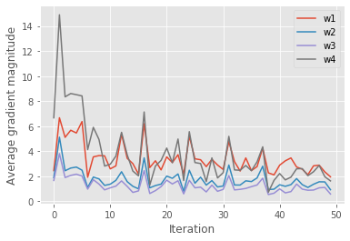

```python
ax = plt.subplot(1,1,1)
plt.plot(clf4.magnitude_gradients[0][10:], label = 'W1' )
plt.plot(clf4.magnitude_gradients[1][10:], label = 'W2' )
plt.plot(clf4.magnitude_gradients[2][10:], label = 'W3' )
plt.plot(clf4.magnitude_gradients[3][10:], label = 'W4' )
plt.legend()
plt.ylabel('Average gradient magnitude')
plt.xlabel('Iteration')
plt.show()
```

### 3.3 Repeat the previous step, adding support for a fifth layer.

```python
class FiveLayerPerceptronBase(object):
    def __init__(self, n_hidden=30,phi_function='sigmoid', cost_function='quadratic', n_layers=5,
                 C=0.0, epochs=500, eta=0.001, random_state=None):
        np.random.seed(random_state)
        self.n_hidden = n_hidden
        self.l2_C = C
        self.epochs = epochs
        self.eta = eta
        self.phi_function = phi_function
        self.cost_function = cost_function
        self.n_layers=n_layers



    @staticmethod
    def _encode_labels(y):
        """Encode labels into one-hot representation"""
        onehot = pd.get_dummies(y).values.T
        return onehot

#now, we have 5 layers, so we have W1, W2,W3,W4,W5

    def _initialize_weights(self):

        W = []
        """Initialize weights with small random numbers."""
        W1_num_elems = (self.n_features_ + 1)*self.n_hidden
        W1 = np.random.uniform(-1.0, 1.0, size=W1_num_elems)
        W1 = W1.reshape(self.n_hidden, self.n_features_ + 1) # reshape to be W

        W2_num_elems = (self.n_hidden + 1)*self.n_hidden
        W2 = np.random.uniform(-1.0, 1.0, size=W2_num_elems)
        W2 = W2.reshape(self.n_hidden, self.n_hidden + 1)

        W3_num_elems = (self.n_hidden + 1)*self.n_hidden
        W3 = np.random.uniform(-1.0, 1.0, size=W3_num_elems)
        W3 = W3.reshape(self.n_hidden, self.n_hidden + 1)

        W4_num_elems = (self.n_hidden + 1)*self.n_hidden
        W4 = np.random.uniform(-1.0, 1.0, size=W4_num_elems)
        W4 = W4.reshape(self.n_hidden, self.n_hidden + 1)

        W5_num_elems = (self.n_hidden + 1)*self.n_output_
        W5 = np.random.uniform(-1.0, 1.0, size=W5_num_elems)
        W5 = W5.reshape(self.n_output_, self.n_hidden + 1)
        W = [W1,W2,W3,W4,W5]
        return W

    @staticmethod
    def _sigmoid(z):
        """Use scipy.special.expit to avoid overflow"""
        # 1.0 / (1.0 + np.exp(-z))
        return expit(z)

    @staticmethod
    def _linear(z):
        return z

    @staticmethod
    def _add_bias_unit(X, how='column'):
        """Add bias unit (column or row of 1s) to array at index 0"""
        if how == 'column':
            ones = np.ones((X.shape[0], 1))
            X_new = np.hstack((ones, X))
        elif how == 'row':
            ones = np.ones((1, X.shape[1]))
            X_new = np.vstack((ones, X))
        return X_new


    @staticmethod
    def _L2_reg(lambda_, W):
        """Compute L2-regularization cost"""
        # only compute for non-bias terms
        return (lambda_/2.0) * np.sqrt(np.mean(W[0][:, 1:] ** 2) + np.mean(W[1][:, 1:] ** 2) +
                                        np.mean(W[2][:, 1:] ** 2) +np.mean(W[3][:, 1:] ** 2)+
                                        np.mean(W[4][:, 1:] ** 2))

    def _cost(self, A_last, Y_enc, W):
        '''Get the objective function value'''
        if 'quadratic' == self.cost_function:
            cost = np.mean((Y_enc - A_last) ** 2)
        elif 'crossentropy' == self.cost_function:
            cost = -np.mean((Y_enc * np.log(A_last) + (1 - Y_enc) * np.log(1 - A_last)))

        L2_term = self._L2_reg(self.l2_C, W)
        return cost + L2_term
```

```python
class FiveLayerPerceptron(FiveLayerPerceptronBase):
    def _feedforward(self, X, W):
        """Compute feedforward step"""
        if  'linear' == self.phi_function:
            activate = self._linear
        elif  'sigmoid' == self.phi_function:
            activate = self._sigmoid
        else:
            raise 'Not a valid of phi_function'

        #Initialize A,Z
        A, Z = [], []
        A.append(self._add_bias_unit(X.T, how='row'))
        Z.append(W[0] @ A[0])
        for i in range(1,self.n_layers):
            A.append(self._add_bias_unit(activate(Z[i-1]), how='row'))
            Z.append(W[i] @ A[i])
        #Last layer A
        A.append(activate(Z[-1]))
        return A,Z

    def _get_gradient(self, A, Z, Y_enc, W):
        """ Compute gradient step using backpropagation."""
        # vectorized backpropagation
        grad, V = [[]] * self.n_layers, [[]] * self.n_layers

        # First
        if 'crossentropy' == self.cost_function:
            V[-1] = A[-1] - Y_enc
        elif 'quadratic' == self.cost_function: # mse
            V[-1] = -2 * (Y_enc-A[-1]) * A[-1] * (1-A[-1])
        else:
            raise 'Not a valid of cost_function'
        grad[-1] = V[-1] @ A[-2].T

        # After first
        for i in range(self.n_layers-2, -1, -1): #We want to start at the last layer, including 0
            if 'linear' == self.phi_function:
                V[i] = W[i+1].T @ V[i+1]
            elif 'sigmoid' == self.phi_function:
                V[i] = A[i+1] * (1-A[i+1]) * (W[i+1].T @ V[i+1])
            V[i] = V[i][1:,:]

            grad[i] = V[i] @ A[i].T

        # regularize weights that are not bias terms
        for i in range(len(grad)):
            grad[i][:, 1:] += W[i][:, 1:] * self.l2_C

        return grad

    def predict(self, X):
        """Predict class labels"""
        A, _ = self._feedforward(X, self.W)
        y_pred = np.argmax(A[-1], axis=0)
        return [self.class_labels_[i] for i in y_pred] #get rid of index

    def fit(self, X, y, print_progress=False):
        """ Learn weights from training data."""

        X_data, y_data = X.copy(), y.copy()
        self.class_labels_ = np.unique(y)
        Y_enc = self._encode_labels(y)

        # init weights and setup matrices
        self.n_features_ = X_data.shape[1]
        self.n_output_ = Y_enc.shape[0]
        self.W = self._initialize_weights()

        self.magnitude_gradients = []
        for i in range(self.n_layers):
            self.magnitude_gradients.append(np.zeros([self.epochs, 1]))

        self.cost_ = []
        self.score_ = []
        gradients = [[]] * self.n_layers
        for epoch in range(self.epochs):
            if print_progress>0 and (epoch+1)%print_progress==0:
                sys.stderr.write('\rEpoch: %d/%d' % (epoch+1, self.epochs))
                sys.stderr.flush()

            # feedforward all instances
            A, Z = self._feedforward(X_data, self.W)
            cost = self._cost(A[-1], Y_enc, self.W)
            self.cost_.append(cost)

            self.score_.append(f1_score(y, self.predict(X_data), average='weighted'))

            # compute gradient via backpropagation
            grad = self._get_gradient(A, Z, Y_enc, self.W)

            for grad_idx in range(len(grad)):
                self.W[grad_idx] -= self.eta * grad[grad_idx]
                gradients[grad_idx].append(np.mean(grad[grad_idx]))

            for layer in range(self.n_layers):
                self.magnitude_gradients[layer][epoch] = average_magnitude(grad[layer])

        self.gradients_ = [[]] * self.n_layers
        for i in range(self.n_layers):
            self.gradients_[i] = np.array(gradients[i])


        return self
```

```python
params5 = dict(n_hidden=50,
              C=0.1, # tradeoff L2 regularizer
              epochs=50, # iterations
              eta=0.001,  # learning rate
              random_state=1)
```

```python
%%time
nn5 = FiveLayerPerceptron(**params5)
clf5 = nn.fit(X_train2, y_train2, print_progress=100)
yhat5 = nn.predict(X_test2)
print('Test acc:',accuracy_score(y_test2,yhat5))
```

```
Test acc: 0.2493124312431243
CPU times: user 52.5 s, sys: 3.33 s, total: 55.8 s
Wall time: 14.1 s
```

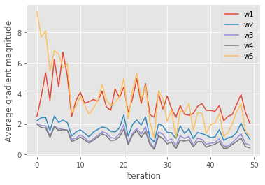

```python
ax = plt.subplot(1,1,1)
plt.plot(clf5.magnitude_gradients[0][10:], label = 'W1' )
plt.plot(clf5.magnitude_gradients[1][10:], label = 'W2' )
plt.plot(clf5.magnitude_gradients[2][10:], label = 'W3' )
plt.plot(clf5.magnitude_gradients[3][10:], label = 'W4' )
plt.plot(clf5.magnitude_gradients[4][10:], label = 'W5' )
plt.legend()
plt.ylabel('Average gradient magnitude')
plt.xlabel('Iteration')
plt.show()
```

### 3.4 Implement an adaptive learning technique that was discussed in lecture and use it on the five layer network. Compare the performance of this model with and without the adaptive learning strategy. Do not use AdaM for the adaptive learning technique.

```python
class FiveLayerPerceptronBase(object):
    def __init__(self, n_hidden=30,phi_function='sigmoid', cost_function='quadratic',decrease_const=0.0001,
                 shuffle=True,C=0.0,minibatches=50,alpha=0.001, epochs=500, eta=0.001, random_state=None):
        np.random.seed(random_state)
        self.n_hidden = n_hidden
        self.l2_C = C
        self.epochs = epochs
        self.eta = eta
        self.alpha = alpha
        self.phi_function = phi_function
        self.cost_function = cost_function
        self.n_layers=5
        self.decrease_const = decrease_const
        self.shuffle = shuffle
        self.minibatches = minibatches



    @staticmethod
    def _encode_labels(y):
        """Encode labels into one-hot representation"""
        onehot = pd.get_dummies(y).values.T
        return onehot

    def _initialize_weights(self):

        W = []
        """Initialize weights with small random numbers."""
        W1_num_elems = (self.n_features_ + 1)*self.n_hidden
        W1 = np.random.uniform(-1.0, 1.0, size=W1_num_elems)
        W1 = W1.reshape(self.n_hidden, self.n_features_ + 1) # reshape to be W

        W2_num_elems = (self.n_hidden + 1)*self.n_hidden
        W2 = np.random.uniform(-1.0, 1.0, size=W2_num_elems)
        W2 = W2.reshape(self.n_hidden, self.n_hidden + 1)

        W3_num_elems = (self.n_hidden + 1)*self.n_hidden
        W3 = np.random.uniform(-1.0, 1.0, size=W3_num_elems)
        W3 = W3.reshape(self.n_hidden, self.n_hidden + 1)

        W4_num_elems = (self.n_hidden + 1)*self.n_hidden
        W4 = np.random.uniform(-1.0, 1.0, size=W4_num_elems)
        W4 = W4.reshape(self.n_hidden, self.n_hidden + 1)

        W5_num_elems = (self.n_hidden + 1)*self.n_output_
        W5 = np.random.uniform(-1.0, 1.0, size=W5_num_elems)
        W5 = W5.reshape(self.n_output_, self.n_hidden + 1)
        W = [W1,W2,W3,W4,W5]
        return W

    @staticmethod
    def _sigmoid(z):
        """Use scipy.special.expit to avoid overflow"""
        # 1.0 / (1.0 + np.exp(-z))
        return expit(z)

    @staticmethod
    def _linear(z):
        return z

    @staticmethod
    def _add_bias_unit(X, how='column'):
        """Add bias unit (column or row of 1s) to array at index 0"""
        if how == 'column':
            ones = np.ones((X.shape[0], 1))
            X_new = np.hstack((ones, X))
        elif how == 'row':
            ones = np.ones((1, X.shape[1]))
            X_new = np.vstack((ones, X))
        return X_new


    @staticmethod
    def _L2_reg(lambda_, W):
        """Compute L2-regularization cost"""
        # only compute for non-bias terms
        k = 0.
        for i in range (len(W)):
            k += np.mean(W[i][:, 1:] ** 2)
        return (lambda_/2.0) * np.sqrt(k)

    def _cost(self, A_last, Y_enc, W):
        '''Get the objective function value'''
        if 'quadratic' == self.cost_function:
            cost = np.mean((Y_enc - A_last) ** 2)
        elif 'crossentropy' == self.cost_function:
            cost = -np.mean((Y_enc * np.log(A_last) + (1 - Y_enc) * np.log(1 - A_last)))

        L2_term = self._L2_reg(self.l2_C, W)
        return cost + L2_term
```

```python
class FiveLayerPerceptron2(FiveLayerPerceptronBase):
    def _feedforward(self, X, W):
        """Compute feedforward step"""
        if  'linear' == self.phi_function:
            activate = self._linear
        elif  'sigmoid' == self.phi_function:
            activate = self._sigmoid
        else:
            raise 'Not a valid of phi_function'

        #Initialize A,Z
        A, Z = [], []
        A.append(self._add_bias_unit(X.T, how='row'))
        Z.append(W[0] @ A[0])
        for i in range(1,self.n_layers):
            A.append(self._add_bias_unit(activate(Z[i-1]), how='row'))
            Z.append(W[i] @ A[i])
        #Last layer A
        A.append(activate(Z[-1]))
        return A,Z

    def _get_gradient(self, A, Z, Y_enc, W):
        """ Compute gradient step using backpropagation."""
        # vectorized backpropagation
        grad, V = [[]] * self.n_layers, [[]] * self.n_layers

        # First
        if 'crossentropy' == self.cost_function:
            V[-1] = A[-1] - Y_enc
        elif 'quadratic' == self.cost_function: # mse
            V[-1] = -2 * (Y_enc-A[-1]) * A[-1] * (1-A[-1])
        else:
            raise 'Not a valid of cost_function'
        grad[-1] = V[-1] @ A[-2].T

        # After first
        for i in range(self.n_layers-2, -1, -1): #We want to start at the last layer, including 0
            if 'linear' == self.phi_function:
                V[i] = W[i+1].T @ V[i+1]
            elif 'sigmoid' == self.phi_function:
                V[i] = A[i+1] * (1-A[i+1]) * (W[i+1].T @ V[i+1])
            V[i] = V[i][1:,:]

            grad[i] = V[i] @ A[i].T

        # regularize weights that are not bias terms
        for i in range(len(grad)):
            grad[i][:, 1:] += W[i][:, 1:] * self.l2_C

        return grad

    def predict(self, X):
        """Predict class labels"""
        A, _ = self._feedforward(X, self.W)
        y_pred = np.argmax(A[-1], axis=0)
        return [self.class_labels_[i] for i in y_pred] #get rid of index

    def fit(self, X, y, print_progress=False):
        """ Learn weights from training data."""

        X_data, y_data = X.copy(), y.copy()
        self.class_labels_ = np.unique(y)
        Y_enc = self._encode_labels(y)

        # init weights and setup matrices
        self.n_features_ = X_data.shape[1]
        self.n_output_ = Y_enc.shape[0]
        self.W = self._initialize_weights()

        self.magnitude_gradients = []

        W_prev_list = []
        for W in self.W:
            delta_W_prev = np.zeros(W.shape)
            W_prev_list += [delta_W_prev]

        self.cost_ = []
        self.score_ = []
        # get starting acc
        self.score_.append(accuracy_score(y_data,self.predict(X_data)))


        for i in range(self.n_layers):
            self.magnitude_gradients.append(np.zeros([self.epochs, 1]))

        self.grad_w_ = self.magnitude_gradients
        """
        we do adaptive learning rate here compared with former model

        """
        for i in range(self.epochs):

            # adaptive learning rate
            self.eta /= (1 + self.decrease_const*i)

            if print_progress>0 and (i+1)%print_progress==0:
                sys.stderr.write('\rEpoch: %d/%d' % (i+1, self.epochs))
                sys.stderr.flush()

            if self.shuffle:
                idx_shuffle = np.random.permutation(y_data.shape[0])
                X_data, Y_enc, y_data = X_data[idx_shuffle], Y_enc[:, idx_shuffle], y_data[idx_shuffle]

            mini = np.array_split(range(y_data.shape[0]), self.minibatches)
            mini_cost = []
            for idx in mini:
                # feedforward
                A_list, Z_list = self._feedforward(X_data[idx], self.W)

                cost = self._cost(A_list[-1], Y_enc[:, idx], self.W)
                mini_cost.append(cost) # this appends cost of mini-batch only

                # compute gradient via backpropagation
                gradients_list = self._get_gradient(A_list, Z_list, Y_enc[:, idx], self.W)


            self.cost_.append(mini_cost)
            self.score_.append(accuracy_score(y_data,self.predict(X_data)))

            for idx in range(len(self.grad_w_)):
                self.grad_w_[idx][i] += np.mean(abs(gradients_list[idx]))
        """
        end

        """
        return self
```

```python
%%time
nn6 = FiveLayerPerceptron2(**params5)
clf = nn6.fit(X_train2, y_train2, print_progress=100)
yhat6 = nn.predict(X_test2)
print('Test acc:',accuracy_score(y_test2,yhat))
```

```
Test acc: 0.2493124312431243
CPU times: user 1min 37s, sys: 9.64 s, total: 1min 47s
Wall time: 27.3 s
```

## Exceptional work

### Implement adaptive momentum (AdaM) in the five layer neural network and quantify the performance.

Adam is an adaptive learning rate method, which means, it computes individual learning rates for different parameters.

Adam can be looked at as a combination of RMSprop (Rmsprop is a gradient-based optimization technique proposed by Geoffrey Hinton) and Stochastic Gradient Descent with momentum. It uses the squared gradients to scale the learning rate like RMSprop and it takes advantage of momentum by using moving average of the gradient instead of gradient itself like SGD with momentum. Let’s take a closer look at how it works.

It can be pretty difficult to grasp that idea for the first time, so if you don’t understand it fully, you should still carry on, you’ll be able to understand how algorithms works anyway. Note, that gradient of the cost function of neural network can be considered a random variable, since it usually evaluated on some small random batch of data. The first moment is mean, and the second moment is uncentered variance.  
Citation:1. https://towardsdatascience.com/adam-latest-trends-in-deep-learning-optimization-6be9a291375c 2.https://wiseodd.github.io/techblog/2016/06/22/nn-optimization/

### One way: insert Adam into our model directly

```python
class FiveLayerPerceptron3(FiveLayerPerceptronBase):
    def _feedforward(self, X, W):
        """Compute feedforward step"""
        if  'linear' == self.phi_function:
            activate = self._linear
        elif  'sigmoid' == self.phi_function:
            activate = self._sigmoid
        else:
            raise 'Not a valid of phi_function'

        #Initialize A,Z
        A, Z = [], []
        A.append(self._add_bias_unit(X.T, how='row'))
        Z.append(W[0] @ A[0])
        for i in range(1,self.n_layers):
            A.append(self._add_bias_unit(activate(Z[i-1]), how='row'))
            Z.append(W[i] @ A[i])
        #Last layer A
        A.append(activate(Z[-1]))
        return A,Z

    def _get_gradient(self, A, Z, Y_enc, W):
        """ Compute gradient step using backpropagation."""
        # vectorized backpropagation
        grad, V = [[]] * self.n_layers, [[]] * self.n_layers

        # First
        if 'crossentropy' == self.cost_function:
            V[-1] = A[-1] - Y_enc
        elif 'quadratic' == self.cost_function: # mse
            V[-1] = -2 * (Y_enc-A[-1]) * A[-1] * (1-A[-1])
        else:
            raise 'Not a valid of cost_function'
        grad[-1] = V[-1] @ A[-2].T

        # After first
        for i in range(self.n_layers-2, -1, -1): #We want to start at the last layer, including 0
            if 'linear' == self.phi_function:
                V[i] = W[i+1].T @ V[i+1]
            elif 'sigmoid' == self.phi_function:
                V[i] = A[i+1] * (1-A[i+1]) * (W[i+1].T @ V[i+1])
            V[i] = V[i][1:,:]

            grad[i] = V[i] @ A[i].T

        # regularize weights that are not bias terms
        for i in range(len(grad)):
            grad[i][:, 1:] += W[i][:, 1:] * self.l2_C

        return grad

    def predict(self, X):
        """Predict class labels"""
        A, _ = self._feedforward(X, self.W)
        y_pred = np.argmax(A[-1], axis=0)
        return [self.class_labels_[i] for i in y_pred] #get rid of index

    def fit(self, X, y, print_progress=False):
        """ Learn weights from training data."""

        X_data, y_data = X.copy(), y.copy()
        self.class_labels_ = np.unique(y)
        Y_enc = self._encode_labels(y)

        # init weights and setup matrices
        self.n_features_ = X_data.shape[1]
        self.n_output_ = Y_enc.shape[0]
        self.W = self._initialize_weights()

        self.magnitude_gradients = []

        W_prev_list = []
        for W in self.W:
            delta_W_prev = np.zeros(W.shape)
            W_prev_list += [delta_W_prev]

        self.cost_ = []
        self.score_ = []
        # get starting acc
        self.score_.append(accuracy_score(y_data,self.predict(X_data)))


        for i in range(self.n_layers):
            self.magnitude_gradients.append(np.zeros([self.epochs, 1]))

        self.grad_w_ = self.magnitude_gradients
        """
        we do adaptive learning rate here compared with former model

        """
        for i in range(self.epochs):

            # adaptive learning rate
            self.eta /= (1 + self.decrease_const*i)

            if print_progress>0 and (i+1)%print_progress==0:
                sys.stderr.write('\rEpoch: %d/%d' % (i+1, self.epochs))
                sys.stderr.flush()

            if self.shuffle:
                idx_shuffle = np.random.permutation(y_data.shape[0])
                X_data, Y_enc, y_data = X_data[idx_shuffle], Y_enc[:, idx_shuffle], y_data[idx_shuffle]

            mini = np.array_split(range(y_data.shape[0]), self.minibatches)
            mini_cost = []
            for idx in mini:
                # feedforward
                A_list, Z_list = self._feedforward(X_data[idx], self.W)

                cost = self._cost(A_list[-1], Y_enc[:, idx], self.W)
                mini_cost.append(cost) # this appends cost of mini-batch only

                # compute gradient via backpropagation
                gradients_list = self._get_gradient(A_list, Z_list, Y_enc[:, idx], self.W)
                """

                 insert adaptive momentum (AdaM) here

                """
                # momentum calculations
                delta_W_list = []
                for gradient in gradients_list:
                    delta_W = self.eta * gradient
                    delta_W_list += [delta_W]

                for idx in range(len(self.W)):
                    self.W[idx] -= (delta_W_list[idx] + (self.alpha * W_prev_list[idx]))
                    W_prev_list[idx] = delta_W_list[idx]

            self.cost_.append(mini_cost)
            self.score_.append(accuracy_score(y_data,self.predict(X_data)))

            for idx in range(len(self.grad_w_)):
                self.grad_w_[idx][i] += np.mean(abs(gradients_list[idx]))
        """
        end

        """
        return self
```

```python
%%time
nn6 = FiveLayerPerceptron3(**params5)
clf = nn6.fit(X_train2, y_train2, print_progress=100)
yhat6 = nn.predict(X_test2)
print('Test acc:',accuracy_score(y_test2,yhat))
```

```
Test acc: 0.2493124312431243
CPU times: user 1min 36s, sys: 9.45 s, total: 1min 45s
Wall time: 26.6 s
```

### The other way--use the adam external

```python
minibatch_size= 50
```

```python
def get_minibatch(X, y, minibatch_size):
    minibatches = []

    X, y = shuffle(X, y)

    for i in range(0, X.shape[0], minibatch_size):
        X_mini = X[i:i + minibatch_size]
        y_mini = y[i:i + minibatch_size]

        minibatches.append((X_mini, y_mini))

    return minibatches
```

```python
def adam(FiveLayerPerceptron2, X_train, y_train, minibatch_size):
    M = {k: np.zeros_like(v) for k, v in FiveLayerPerceptron2.items()}
    R = {k: np.zeros_like(v) for k, v in FiveLayerPerceptron2.items()}
    beta1 = .9
    beta2 = .999

    minibatches = get_minibatch(X_train, y_train, minibatch_size)

    for iter in range(1, n_iter + 1):
        t = iter
        idx = np.random.randint(0, len(minibatches))
        X_mini, y_mini = minibatches[idx]

        grad = get_minibatch_grad(FiveLayerPerceptron2, X_mini, y_mini)

        for k in grad:
            M[k] = beta1 * M[k] + (1. - beta1) * grad[k]
            R[k] = beta2 * R[k] + (1. - beta2) * grad[k]**2

            m_k_hat = M[k] / (1. - beta1**(t))
            r_k_hat = R[k] / (1. - beta2**(t))

            FiveLayerPerceptron2[k] += alpha * m_k_hat / (np.sqrt(r_k_hat) + eps)

    return FiveLayerPerceptron2
```

```python
%%time
nn = FiveLayerPerceptron2(**params5)
clf = nn.fit(X_train2, y_train2, print_progress=100)
yhat = nn.predict(X_test2)
print('Test acc:',accuracy_score(y_test2,yhat))
```

```
Test acc: 0.2493124312431243
CPU times: user 1min 32s, sys: 9.26 s, total: 1min 42s
Wall time: 25.7 s
```